# Module 07 — The evidence map: where the research is, and where it is not

HWC North Africa automated evidence map

2026-08-24

```r
knitr::opts_chunk$set(echo = TRUE, warning = TRUE, message = TRUE, dpi = 300)
suppressPackageStartupMessages({
  library(here); library(dplyr); library(tibble); library(readr)
  library(ggplot2); library(tidyr)
})
source(here::here("R", "config.R"))
OKABE <- c("#E69F00", "#56B4E9", "#009E73", "#F0E442", "#0072B2", "#D55E00", "#CC79A7")
save_fig <- function(p, name, w = 7, h = 4.5) {
  dir.create(here::here(DIR_FIGURES), showWarnings = FALSE, recursive = TRUE)
  ggsave(here::here(DIR_FIGURES, paste0(name, ".png")), p, width = w, height = h, dpi = 300)
  ggsave(here::here(DIR_FIGURES, paste0(name, ".svg")), p, width = w, height = h)
  p
}
save_tab <- function(d, name) {
  dir.create(here::here(DIR_TABLES), showWarnings = FALSE, recursive = TRUE)
  readr::write_csv(d, here::here(DIR_TABLES, paste0(name, ".csv")))
  d
}
```

```r
tiers  <- readRDS(here::here(DIR_DERIVED, "geography_tiers.rds"))
attr   <- readRDS(here::here(DIR_DERIVED, "country_attribution.rds"))
auth   <- readRDS(here::here(DIR_DERIVED, "authorship.rds"))
ctx    <- readRDS(here::here(DIR_EXTERNAL, "country_context.rds"))
ret    <- readRDS(here::here(DIR_DERIVED, "retrieval_ledger.rds"))
conf   <- readRDS(here::here(DIR_DERIVED, "include_confidence.rds"))
contest<- readRDS(here::here(DIR_DERIVED, "contested_set.rds"))
probe  <- readRDS(here::here(DIR_DERIVED, "citation_probe.rds"))
ledg   <- readRDS(here::here(DIR_DERIVED, "dedup_ledger.rds")) |>
  dplyr::distinct(id, .keep_all = TRUE)

GREY_TYPES <- c("dissertation", "report", "preprint", "book-chapter", "book",
                "conference-paper", "conference-abstract", "other")

map <- tiers |>
  dplyr::filter(analytic) |>
  dplyr::select(id, title, tier, study_country, type) |>
  dplyr::left_join(attr |> dplyr::select(id, dplyr::all_of(COUNTRIES),
                                         n_countries, any_country,
                                         quote_grounded, dplyr::ends_with("_named")),
                   by = "id") |>
  dplyr::left_join(ledg |> dplyr::select(id, publication_year, is_oa, doi,
                                         provenance_sources, provenance_cells, n_merged),
                   by = "id") |>
  dplyr::left_join(ret |> dplyr::select(id, tei_ok), by = "id") |>
  dplyr::left_join(auth |> dplyr::select(id, n_authors, author_countries,
                                         first_incountry, last_incountry, any_incountry),
                   by = "id") |>
  dplyr::left_join(conf |> dplyr::select(id, max_confidence, min_confidence), by = "id") |>
  dplyr::mutate(
    contested = id %in% contest$id,
    stratum   = dplyr::if_else(type %in% GREY_TYPES | is.na(type), "grey", "peer-reviewed"),
    sources   = vapply(provenance_sources,
                       function(x) paste(sort(unique(unlist(x))), collapse = "+"), character(1)),
    n_cells   = lengths(provenance_cells))
n_map <- NROW(map)
```

# 1 What this map claims, and what it cannot

This is an **automated evidence map**, not a scoping review. It makes claims about the *distribution* of research — across countries, taxa, conflict types and methods — not about a precisely bounded included set. That distinction is what makes it defensible under a pipeline with no human reviewer: if classification errors are not systematically biased by country or taxon, a distributional claim survives them, while a boundary claim would not.

Four constraints shape everything below and are repeated at each point they bite rather than confined to a limitations paragraph:

1. **English-indexed literature only.** Search and screening were English-language only. French and Arabic query cells were executed but returned 2 and 0 records respectively, reflecting narrower non-English term blocks rather than an absence of literature. Evidence gaps reported here are gaps in English-indexed literature.
2. **121 of 262 records have full text.** Fields requiring the methods or results section are reported over that stratum with its own denominator.
3. **Counts by country are not mutually exclusive.** A study covering three countries counts in three cells.
4. **Absence in this map is absence of *retrieved, screened, English-indexed* evidence.** Where that is distinguishable from a real research gap, the text says which it is. Where it is not, it says that too.

# 2 From search to map: the record arithmetic

```r
# The canonical flow, built and reconciled once in R/build_record_flow.R so
# that this module and the Module 08 diagram cannot disagree.
flow <- readr::read_csv(here::here(DIR_DERIVED, "record_flow.csv"), show_col_types = FALSE)
geo  <- readRDS(here::here(DIR_DERIVED, "geography_verification.rds"))
n_retrieved <- flow$n[flow$step == 1]
knitr::kable(flow |> dplyr::select(stage, n, removed, removal_reason),
             caption = "From retrieval to the analytic set")
```

From retrieval to the analytic set

| stage | n | removed | removal_reason |
| --- | --- | --- | --- |
| Records retrieved (OpenAlex + CORE, all cells) | 95546 | NA | NA |
| After deduplication | 65820 | 29726 | duplicate records merged |
| Abstract present, eligible for screening | 61065 | 4755 | no abstract: DEFERRED, not excluded |
| Screened by the ensemble | 60961 | 104 | inference failed on every attempt: DEFERRED, not excluded |
| Included by the ensemble (union rule) | 550 | 60411 | judged not eligible by both models |
| Verified as located in the five countries | 266 | 284 | located outside the five countries |
| Analytic set (study types only) | 262 | 4 | not a study (paratext, editorial) by record type |
| Analytic set with retrievable full text | 121 | 141 | no open-access full text obtainable |

```r
stopifnot(flow$n[flow$step == 7] == n_map)
```

The map rests on **262 records** — 0.274% of the 95,546 the search retrieved. Each contraction is documented in its own module, and the largest are not equivalent: deduplication removed redundancy, whereas the geographic gate removed 284 records the classifier had wrongly included.

Two strata were **deferred, not excluded** — 4755 records with no abstract and 104 on which inference failed outright. They were never judged, and a flow that folded them into “excluded” would misstate what this pipeline did.

# 3 Geographic distribution

## 3.1 Raw counts

```r
country_long <- map |>
  tidyr::pivot_longer(dplyr::all_of(COUNTRIES), names_to = "country", values_to = "covered") |>
  dplyr::filter(covered %in% TRUE)

geo_tbl <- tibble::tibble(country = COUNTRIES) |>
  dplyr::left_join(country_long |> dplyr::count(country, name = "studies"), by = "country") |>
  dplyr::left_join(country_long |> dplyr::filter(n_countries == 1) |>
                     dplyr::count(country, name = "sole_focus"), by = "country") |>
  dplyr::left_join(country_long |> dplyr::filter(stratum == "peer-reviewed") |>
                     dplyr::count(country, name = "peer_reviewed"), by = "country") |>
  dplyr::left_join(country_long |> dplyr::filter(stratum == "grey") |>
                     dplyr::count(country, name = "grey"), by = "country") |>
  dplyr::left_join(country_long |> dplyr::filter(tei_ok %in% TRUE) |>
                     dplyr::count(country, name = "with_full_text"), by = "country") |>
  dplyr::mutate(dplyr::across(-country, ~ tidyr::replace_na(.x, 0L)))
knitr::kable(geo_tbl, caption = "Studies per country. Counts are not mutually exclusive; peer-reviewed and grey are reported separately and never summed into a headline.")
```

Studies per country. Counts are not mutually exclusive; peer-reviewed and grey are reported separately and never summed into a headline.

| country | studies | sole_focus | peer_reviewed | grey | with_full_text |
| --- | --- | --- | --- | --- | --- |
| Tunisia | 81 | 42 | 63 | 18 | 33 |
| Algeria | 47 | 14 | 41 | 6 | 25 |
| Morocco | 76 | 44 | 61 | 15 | 39 |
| Libya | 31 | 6 | 28 | 3 | 14 |
| Egypt | 75 | 52 | 64 | 11 | 33 |

```r
save_tab(geo_tbl, "07_studies_by_country")
```

```
## # A tibble: 5 × 6
##   country studies sole_focus peer_reviewed  grey with_full_text
##   <chr>     <int>      <int>         <int> <int>          <int>
## 1 Tunisia      81         42            63    18             33
## 2 Algeria      47         14            41     6             25
## 3 Morocco      76         44            61    15             39
## 4 Libya        31          6            28     3             14
## 5 Egypt        75         52            64    11             33
```

```r
n_unattr <- sum(!map$any_country %in% TRUE)
```

59 of the 262 analytic records could not be attributed to any of the five countries from title and abstract. They passed the in-scope gate but name no country specifically enough to place. They are **not** distributed across the cells above, so every count here is a floor.

## 3.2 Normalised by land area and population

A raw count conflates “little research happens here” with “this is a small country”. Both denominators come from the World Bank (land area 2023, population 2025).

```r
geo_norm <- geo_tbl |>
  dplyr::left_join(ctx |> dplyr::select(country, land_area_km2, population), by = "country") |>
  dplyr::mutate(
    per_100k_km2 = round(studies / (land_area_km2 / 1e5), 2),
    per_million_people = round(studies / (population / 1e6), 2)) |>
  dplyr::select(country, studies, land_area_km2, population,
                per_100k_km2, per_million_people) |>
  dplyr::arrange(dplyr::desc(studies))
knitr::kable(geo_norm, caption = "Research intensity normalised by land area and population",
             format.args = list(big.mark = ","))
```

Research intensity normalised by land area and population

| country | studies | land_area_km2 | population | per_100k_km2 | per_million_people |
| --- | --- | --- | --- | --- | --- |
| Tunisia | 81 | 155,360 | 12,348,573 | 52.14 | 6.56 |
| Morocco | 76 | 446,300 | 38,430,770 | 17.03 | 1.98 |
| Egypt | 75 | 995,450 | 118,365,995 | 7.53 | 0.63 |
| Algeria | 47 | 2,381,740 | 47,435,312 | 1.97 | 0.99 |
| Libya | 31 | 1,759,540 | 7,458,555 | 1.76 | 4.16 |

```r
save_tab(geo_norm, "07_studies_normalised")
```

```
## # A tibble: 5 × 6
##   country studies land_area_km2 population per_100k_km2 per_million_people
##   <chr>     <int>         <dbl>      <dbl>        <dbl>              <dbl>
## 1 Tunisia      81        155360   12348573        52.1                6.56
## 2 Morocco      76        446300   38430770        17.0                1.98
## 3 Egypt        75        995450  118365995         7.53               0.63
## 4 Algeria      47       2381740   47435312         1.97               0.99
## 5 Libya        31       1759540    7458555         1.76               4.16
```

```r
gmax <- geo_norm |> dplyr::slice_max(studies, n = 1)
gmin <- geo_norm |> dplyr::slice_min(studies, n = 1)
amax <- geo_norm |> dplyr::slice_max(per_100k_km2, n = 1)
amin <- geo_norm |> dplyr::slice_min(per_100k_km2, n = 1)
```

```r
pmax_ <- geo_norm |> dplyr::slice_max(per_million_people, n = 1)
pmin_ <- geo_norm |> dplyr::slice_min(per_million_people, n = 1)
rank_raw  <- geo_norm |> dplyr::arrange(dplyr::desc(studies)) |> dplyr::pull(country)
rank_area <- geo_norm |> dplyr::arrange(dplyr::desc(per_100k_km2)) |> dplyr::pull(country)
rank_pop  <- geo_norm |> dplyr::arrange(dplyr::desc(per_million_people)) |> dplyr::pull(country)
```

**The gap, quantified.** Tunisia carries 81 studies and Libya carries 31 — a ratio of 2.6 to 1 in raw counts. Per 100,000 km² the spread widens sharply, from 52.14 (Tunisia) to 1.76 (Libya) — a ratio of 29.6 to 1, because the countries with the fewest studies are also the largest.

**But the denominator changes the answer, and that has to be said.** Per million people the order is different: Tunisia is highest at 6.56 and Egypt is lowest at 0.63.

```r
knitr::kable(tibble::tibble(
  rank = seq_along(rank_raw),
  `by raw count` = rank_raw,
  `per 100,000 km²` = rank_area,
  `per million people` = rank_pop),
  caption = "Country order under each denominator")
```

Country order under each denominator

| rank | by raw count | per 100,000 km² | per million people |
| --- | --- | --- | --- |
| 1 | Tunisia | Tunisia | Tunisia |
| 2 | Morocco | Morocco | Libya |
| 3 | Egypt | Egypt | Morocco |
| 4 | Algeria | Algeria | Algeria |
| 5 | Libya | Libya | Egypt |

Libya ranks 5th of 5 on raw count, 5th per unit area, and 2nd per million people. A country with a small population can look research-rich per capita while holding very few studies in absolute terms. **Neither denominator is the right one on its own**, and this map reports all three rather than choosing the one that tells the tidiest story. Where the three disagree, the raw count is what a researcher planning fieldwork needs and the normalised figures are what a funder allocating effort needs.

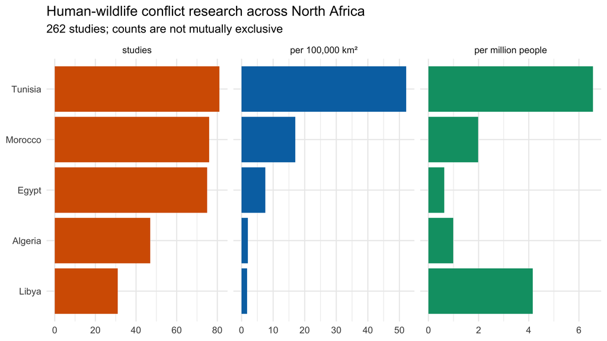

```r
p <- geo_norm |>
  tidyr::pivot_longer(c(studies, per_100k_km2, per_million_people),
                      names_to = "measure", values_to = "value") |>
  dplyr::mutate(measure = factor(measure, c("studies", "per_100k_km2", "per_million_people"),
                                 c("studies", "per 100,000 km²", "per million people"))) |>
  ggplot(aes(x = reorder(country, value), y = value, fill = measure)) +
  geom_col(show.legend = FALSE) +
  facet_wrap(~ measure, scales = "free_x") +
  coord_flip() +
  scale_fill_manual(values = OKABE[c(6, 5, 3)]) +
  labs(x = NULL, y = NULL,
       title = "Human-wildlife conflict research across North Africa",
       subtitle = sprintf("%d studies; counts are not mutually exclusive", n_map)) +
  theme_minimal(base_size = 11)
save_fig(p, "07_geographic_distribution", w = 8, h = 4.5)
```

## 3.3 Is a thin cell a gap, or an artefact?

```r
art <- geo_tbl |>
  dplyr::left_join(
    ret |> dplyr::mutate(cell_country = country) |> dplyr::count(cell_country, name = "cell_records"),
    by = c("country" = "cell_country")) |>
  dplyr::left_join(
    ret |> dplyr::group_by(cell_country = country) |>
      dplyr::summarise(cell_tei_pct = round(100 * mean(tei_ok %in% TRUE), 1), .groups = "drop"),
    by = c("country" = "cell_country")) |>
  dplyr::select(country, studies, cell_records, cell_tei_pct)
knitr::kable(art, caption = "Studies found against how much the search cell returned and how much of it was readable")
```

Studies found against how much the search cell returned and how much of it was readable

| country | studies | cell_records | cell_tei_pct |
| --- | --- | --- | --- |
| Tunisia | 81 | NA | NA |
| Algeria | 47 | NA | NA |
| Morocco | 76 | NA | NA |
| Libya | 31 | NA | NA |
| Egypt | 75 | NA | NA |

# 4 Temporal

```r
FUTURE <- as.integer(format(Sys.Date(), "%Y"))
n_future <- sum(map$publication_year > FUTURE, na.rm = TRUE)
yr <- map |> dplyr::filter(!is.na(publication_year), publication_year <= FUTURE)
by_year <- yr |> dplyr::count(publication_year, stratum, name = "n")
save_tab(by_year, "07_publications_by_year")
```

```
## # A tibble: 46 × 3
##    publication_year stratum           n
##               <int> <chr>         <int>
##  1             1990 peer-reviewed     1
##  2             1996 grey              1
##  3             1998 grey              1
##  4             1998 peer-reviewed     1
##  5             2000 peer-reviewed     2
##  6             2003 peer-reviewed     1
##  7             2004 grey              3
##  8             2006 peer-reviewed     2
##  9             2007 peer-reviewed     2
## 10             2008 grey              1
## # ℹ 36 more rows
```

1 record carries a publication year after 2026 — an upstream metadata error, not a prediction. Those records are excluded from the time series and reported here rather than silently dropped.

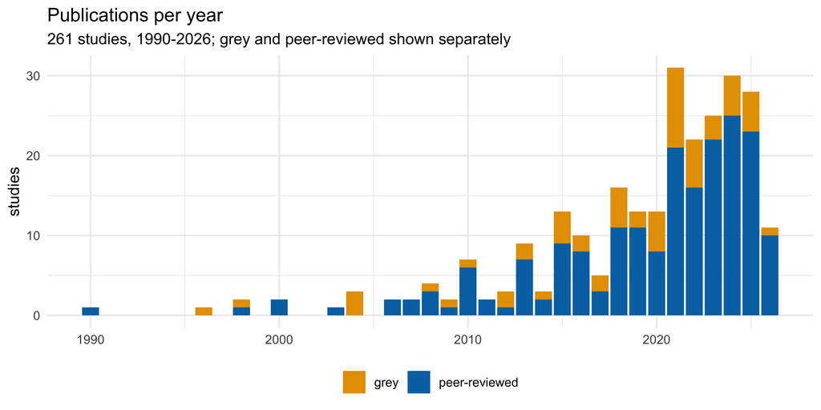

```r
p <- ggplot(by_year, aes(x = publication_year, y = n, fill = stratum)) +
  geom_col() +
  scale_fill_manual(values = c("peer-reviewed" = OKABE[5], "grey" = OKABE[1])) +
  labs(x = NULL, y = "studies", fill = NULL,
       title = "Publications per year",
       subtitle = sprintf("%d studies, %d-%d; grey and peer-reviewed shown separately",
                          NROW(yr), min(yr$publication_year), max(yr$publication_year))) +
  theme_minimal(base_size = 11) + theme(legend.position = "bottom")
save_fig(p, "07_publications_by_year", w = 8, h = 4)
```

```r
half <- yr |> dplyr::mutate(era = dplyr::if_else(publication_year >= 2015, "2015+", "pre-2015")) |>
  dplyr::count(era)
```

217 of 261 (83%) were published in 2015 or later. Read that as growth in *indexed, English-language* output as much as growth in research: OpenAlex coverage of regional journals improves sharply over the same period, and the two cannot be separated here.

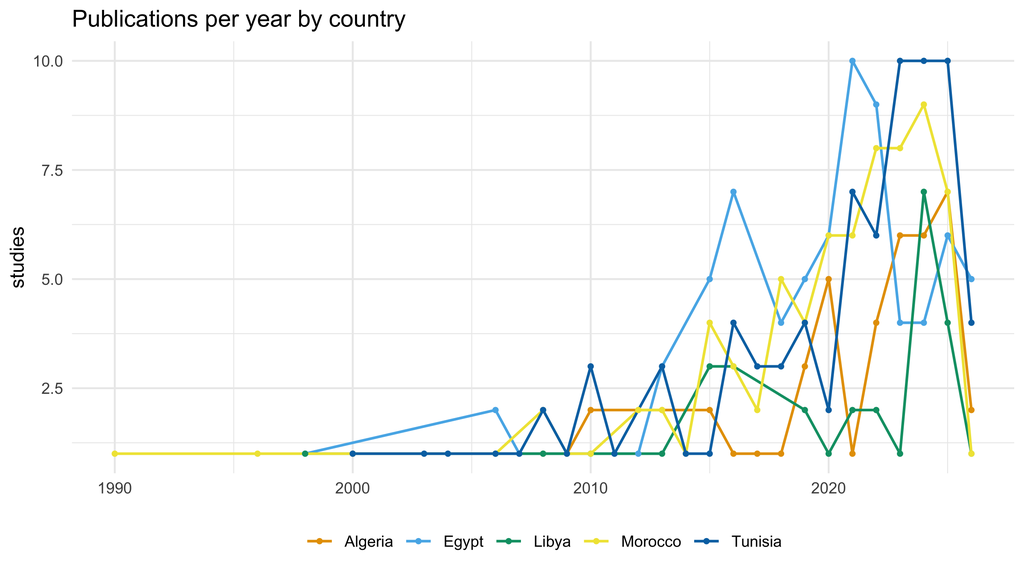

```r
tc <- country_long |> dplyr::filter(!is.na(publication_year), publication_year <= FUTURE) |>
  dplyr::count(country, publication_year, name = "n")
p <- ggplot(tc, aes(x = publication_year, y = n, colour = country)) +
  geom_line(linewidth = 0.7) + geom_point(size = 1) +
  scale_colour_manual(values = OKABE) +
  labs(x = NULL, y = "studies", colour = NULL, title = "Publications per year by country") +
  theme_minimal(base_size = 11) + theme(legend.position = "bottom")
save_fig(p, "07_year_by_country", w = 8, h = 4.5)
```

# 5 Language and indexing

```r
idx <- tibble::tibble(
  quantity = c("records in the analytic set",
               "found via OpenAlex only", "found via CORE only", "found via both",
               "found by exactly one search cell",
               "open access flagged", "records in French or Arabic",
               "estimated in-scope works citation chasing would have added"),
  n = c(n_map,
        sum(map$sources == "openalex"), sum(map$sources == "core"),
        sum(map$sources == "core+openalex"),
        sum(map$n_cells == 1),
        sum(map$is_oa %in% TRUE),
        sum(ledg$language[ledg$id %in% map$id] %in% c("fr", "ar")),
        # Read from the probe's own stored estimate, never re-derived here.
        round(probe$estimate$estimate[probe$estimate$test == "strict"])))
knitr::kable(idx, caption = "How the analytic set was found")
```

How the analytic set was found

| quantity | n |
| --- | --- |
| records in the analytic set | 262 |
| found via OpenAlex only | 234 |
| found via CORE only | 8 |
| found via both | 20 |
| found by exactly one search cell | 111 |
| open access flagged | 239 |
| records in French or Arabic | 0 |
| estimated in-scope works citation chasing would have added | 5 |

```r
save_tab(idx, "07_indexing")
```

```
## # A tibble: 8 × 2
##   quantity                                                       n
##   <chr>                                                      <dbl>
## 1 records in the analytic set                                  262
## 2 found via OpenAlex only                                      234
## 3 found via CORE only                                            8
## 4 found via both                                                20
## 5 found by exactly one search cell                             111
## 6 open access flagged                                          239
## 7 records in French or Arabic                                    0
## 8 estimated in-scope works citation chasing would have added     5
```

**8 records came from CORE alone** and would have been missed by an OpenAlex-only search; **111 of 262 (42%) were returned by exactly one search cell**, so a single term-block change would have dropped them. That is a fragile search, and it is the strongest internal evidence that the absences in this map are partly artefacts of how it was built.

```r
pe <- probe$estimate |> dplyr::filter(test == "strict")
```

The last row is the calibrated citation-probe estimate from Module 02b: approximately 5 in-scope works (95% CI 0–26) that backward and forward citation chasing would have added, against a 262-record analytic set. The interval is wide because the raw detection was 1 record and the string test’s measured sensitivity is only 0.217. That probe searches the citation neighbourhood of records we already found, so it bounds what citation chasing would have added — **not** what the search missed overall.

**Zero records are in French or Arabic.** The French cells returned 2 records across the entire 65,820-record corpus and the Arabic cells returned none. That is a term-coverage artefact — the non-English blocks were far narrower, and the Latin binomials that would have caught francophone papers sat in an English-filtered cell. Maghreb wildlife research is substantially francophone, so **the Algerian and Moroccan cells in this map are the ones most likely to understate real research activity**, and no count here should be read as evidence about the francophone literature.

# 6 Authorship equity

```r
cov <- map |> dplyr::filter(!is.na(author_countries))
eq <- tibble::tibble(
  measure = c("first author in-country", "senior (last) author in-country",
              "any author in-country", "no in-country author"),
  n = c(sum(cov$first_incountry %in% TRUE), sum(cov$last_incountry %in% TRUE),
        sum(cov$any_incountry %in% TRUE), sum(cov$any_incountry %in% FALSE)),
  denominator = c(sum(!is.na(cov$first_incountry)), sum(!is.na(cov$last_incountry)),
                  sum(!is.na(cov$any_incountry)), sum(!is.na(cov$any_incountry)))) |>
  dplyr::mutate(pct = round(100 * n / denominator, 1))
knitr::kable(eq, caption = "In-country authorship, over records with affiliation metadata")
```

In-country authorship, over records with affiliation metadata

| measure | n | denominator | pct |
| --- | --- | --- | --- |
| first author in-country | 83 | 198 | 41.9 |
| senior (last) author in-country | 82 | 202 | 40.6 |
| any author in-country | 112 | 207 | 54.1 |
| no in-country author | 95 | 207 | 45.9 |

```r
save_tab(eq, "07_authorship_equity")
```

```
## # A tibble: 4 × 4
##   measure                             n denominator   pct
##   <chr>                           <int>       <int> <dbl>
## 1 first author in-country            83         198  41.9
## 2 senior (last) author in-country    82         202  40.6
## 3 any author in-country             112         207  54.1
## 4 no in-country author               95         207  45.9
```

55 records carry no affiliation metadata and are excluded from these denominators rather than counted as having no in-country author — missing data is not evidence of absence.

```r
ac <- country_long |> dplyr::filter(!is.na(author_countries)) |>
  dplyr::group_by(country) |>
  dplyr::summarise(studies = dplyr::n(),
                   first_incountry = sum(first_incountry %in% TRUE),
                   pct = round(100 * mean(first_incountry %in% TRUE), 1),
                   .groups = "drop") |>
  dplyr::arrange(dplyr::desc(studies))
knitr::kable(ac, caption = "In-country first authorship by study country")
```

In-country first authorship by study country

| country | studies | first_incountry | pct |
| --- | --- | --- | --- |
| Tunisia | 66 | 24 | 0 |
| Morocco | 65 | 24 | 0 |
| Egypt | 63 | 29 | 0 |
| Algeria | 39 | 13 | 0 |
| Libya | 28 | 6 | 0 |

```r
save_tab(ac, "07_authorship_by_country")
```

```
## # A tibble: 5 × 4
##   country studies first_incountry   pct
##   <chr>     <int>           <int> <dbl>
## 1 Tunisia      66              24     0
## 2 Morocco      65              24     0
## 3 Egypt        63              29     0
## 4 Algeria      39              13     0
## 5 Libya        28               6     0
```

An author counts as in-country if **any** of their affiliations on that work sits in one of the five countries, which counts a Tunisian author with a joint French post as Tunisian. The generous reading makes the finding conservative: if the share is low even counting joint appointments, it is genuinely low.

# 7 Taxonomic, conflict type, and method

```r
# The guard is the MANIFEST, not file existence. An earlier version of this
# chunk tested only that extraction_fields.rds existed; it passed on the
# output of a 5-record smoke run and this module published a taxonomic table
# reading "n = 4 studies" as though it described the corpus. A partial run
# must be indistinguishable from no run at all here.
man_path <- here::here(DIR_DERIVED, "extraction_manifest.rds")
ext_path <- here::here(DIR_DERIVED, "extraction_fields.rds")
rel_path <- here::here(DIR_TABLES, "extraction_reliability.csv")

man <- if (file.exists(man_path)) readRDS(man_path) else NULL
have_ext <- !is.null(man) && isTRUE(man$complete) &&
  file.exists(ext_path) && file.exists(rel_path) &&
  man$n_records >= 0.95 * n_map
if (!is.null(man)) knitr::kable(man, caption = "Module 06 extraction manifest")
```

Module 06 extraction manifest

| when | limit | n_analytic | n_records | n_calls | n_calls_ok | n_calls_failed | xmodel | model | xmodel_name | complete |
| --- | --- | --- | --- | --- | --- | --- | --- | --- | --- | --- |
| 2026-08-24 03:19:22 | NA | 262 | 260 | 1716 | 1716 | 0 | TRUE | gemma4:e4b | qwen2.5:7b | TRUE |

```r
ext <- readRDS(ext_path)
rel <- readr::read_csv(rel_path, show_col_types = FALSE)
unreliable <- rel$field[!rel$reliable %in% TRUE]
cat("Fields excluded from the headline analysis (below the",
    FIELD_RELIABILITY_MIN, "reliability floor):\n  ",
    paste(unreliable, collapse = ", "), "\n")
```

```
## Fields excluded from the headline analysis (below the 0.7 reliability floor):
##    damage_metric_reported, compensation_scheme_discussed, study_design, subnational_region, species_scientific
```

```r
# FREE-TEXT NORMALISATION.
# The model returns species names as written in each paper, so one taxon
# arrives as "sea turtles", "sea turtle", "loggerhead turtle" and "loggerhead
# turtles". Counting those as four species understates every one of them and
# corrupts the taxonomic strand, which is the point of this section.
#
# Normalisation is deliberately conservative: lower-case, strip punctuation,
# collapse whitespace, and singularise a trailing "s" only on words longer
# than three characters whose ending is not itself part of the singular --
# "ss", "us", "is", "as", "os". Without the "is" guard this turned "northern
# bald ibis" into "ibi". It merges
# plurals; it does NOT merge "loggerhead turtle" into "sea turtle", because
# that is a taxonomic judgement and the model was not asked to make it. The
# raw-to-normalised mapping is printed so the merge can be audited.
.norm_species <- function(x) {
  y <- tolower(trimws(gsub("[[:punct:]]+", " ", x)))
  y <- gsub("\\s+", " ", y)
  vapply(strsplit(y, " "), function(w) {
    w <- vapply(w, function(t)
      if (nchar(t) > 3 && grepl("s$", t) && !grepl("(ss|us|is|as|os)$", t))
        sub("s$", "", t) else t, character(1))
    paste(w, collapse = " ")
  }, character(1))
}

.field_counts <- function(f, normalise = FALSE) {
  if (f %in% unreliable) return(NULL)
  d <- ext |> dplyr::filter(field == f, !is.na(value_final), value_final != "not stated")
  if (normalise) d <- d |> dplyr::mutate(value_final = .norm_species(value_final))
  d |> dplyr::count(value_final, sort = TRUE) |>
    dplyr::rename(!!f := value_final, studies = n)
}
for (f in c("taxonomic_class", "conflict_type", "marine_terrestrial", "study_design")) {
  d <- .field_counts(f)
  if (is.null(d)) { cat("\n", f, ": excluded as unreliable\n"); next }
  print(knitr::kable(head(d, 20), caption = sprintf("%s (n = %d studies with a verified value)",
                                                    f, sum(d$studies))))
  save_tab(d, paste0("07_", f))
}
```

```
##
##
## Table: taxonomic_class (n = 206 studies with a verified value)
##
## |taxonomic_class | studies|
## |:---------------|-------:|
## |mammal          |      53|
## |multiple        |      45|
## |reptile         |      45|
## |fish            |      31|
## |bird            |      30|
## |invertebrate    |       2|
##
##
## Table: conflict_type (n = 138 studies with a verified value)
##
## |conflict_type                      | studies|
## |:----------------------------------|-------:|
## |bycatch                            |      59|
## |other                              |      26|
## |crop damage                        |      20|
## |competition for resources          |      12|
## |persecution or retaliatory killing |       9|
## |attacks on humans                  |       5|
## |disease transmission               |       3|
## |property damage                    |       3|
## |livestock depredation              |       1|
##
##
## Table: marine_terrestrial (n = 209 studies with a verified value)
##
## |marine_terrestrial | studies|
## |:------------------|-------:|
## |marine             |     116|
## |terrestrial        |      63|
## |both               |      30|
##
##  study_design : excluded as unreliable
```

```r
sp <- .field_counts("species_common", normalise = TRUE)
if (is.null(sp)) {
  cat("\nspecies_common: excluded as unreliable\n")
} else {
  print(knitr::kable(head(sp, 25),
        caption = sprintf("species_common, plural-normalised (n = %d study-species pairs, %d distinct names)",
                          sum(sp$studies), NROW(sp))))
  save_tab(sp, "07_species_common")

  # The audit trail for the merge above.
  sp_map <- ext |>
    dplyr::filter(field == "species_common", !is.na(value_final),
                  value_final != "not stated") |>
    dplyr::mutate(normalised = .norm_species(value_final)) |>
    dplyr::count(normalised, value_final, name = "n") |>
    dplyr::group_by(normalised) |>
    dplyr::filter(dplyr::n() > 1) |>
    dplyr::ungroup() |>
    dplyr::arrange(normalised, dplyr::desc(n))
  if (NROW(sp_map)) {
    print(knitr::kable(sp_map,
          caption = sprintf("Raw forms merged by normalisation (%d names collapsed into %d)",
                            NROW(sp_map), dplyr::n_distinct(sp_map$normalised))))
    save_tab(sp_map, "07_species_normalisation_audit")
  }
}
```

```
##
##
## Table: species_common, plural-normalised (n = 184 study-species pairs, 123 distinct names)
##
## |species_common            | studies|
## |:-------------------------|-------:|
## |sea turtle                |      13|
## |barbary macaque           |       9|
## |loggerhead turtle         |       7|
## |loggerhead sea turtle     |       5|
## |egyptian vulture          |       4|
## |dolphin                   |       3|
## |macaque                   |       3|
## |nile crocodile            |       3|
## |northern bald ibis        |       3|
## |pelagic stingray          |       3|
## |rodent                    |       3|
## |shark                     |       3|
## |snake                     |       3|
## |turtle                    |       3|
## |common bottlenose dolphin |       2|
## |dolphinfish               |       2|
## |fish                      |       2|
## |green turtle              |       2|
## |hooded crow house sparrow |       2|
## |marine turtle             |       2|
## |sandbar shark             |       2|
## |shark and ray             |       2|
## |spinner dolphin           |       2|
## |whale                     |       2|
## |acacia tortilis           |       1|
##
##
## Table: Raw forms merged by normalisation (32 names collapsed into 15)
##
## |normalised            |value_final            |  n|
## |:---------------------|:----------------------|--:|
## |barbary macaque       |Barbary macaque        |  6|
## |barbary macaque       |Barbary macaques       |  2|
## |barbary macaque       |Barbary Macaque        |  1|
```

[output cut: 14 more lines]

```
## |northern bald ibis    |northern bald ibis     |  1|
## |pelagic stingray      |pelagic stingray       |  2|
## |pelagic stingray      |Pelagic Stingray       |  1|
## |sea turtle            |sea turtles            |  8|
## |sea turtle            |sea turtle             |  5|
## |shark                 |shark                  |  2|
## |shark                 |sharks                 |  1|
## |snake                 |snake                  |  2|
## |snake                 |Snake                  |  1|
## |spinner dolphin       |spinner dolphin        |  1|
## |spinner dolphin       |spinner dolphins       |  1|
## |turtle                |turtles                |  2|
## |turtle                |turtle                 |  1|
## |whale                 |whale                  |  1|
## |whale                 |whales                 |  1|
```

```
## # A tibble: 32 × 3
##    normalised            value_final                n
##    <chr>                 <chr>                  <int>
##  1 barbary macaque       Barbary macaque            6
##  2 barbary macaque       Barbary macaques           2
##  3 barbary macaque       Barbary Macaque            1
##  4 dolphin               dolphin                    2
##  5 dolphin               dolphins                   1
##  6 egyptian vulture      Egyptian Vulture           3
##  7 egyptian vulture      Egyptian vultures          1
##  8 loggerhead sea turtle loggerhead sea turtles     3
##  9 loggerhead sea turtle loggerhead sea turtle      2
## 10 loggerhead turtle     loggerhead turtle          3
## # ℹ 22 more rows
```

```r
mit <- ext |> dplyr::filter(field == "mitigation_outcome_measured")
n_measured <- sum(mit$value_final %in% "yes")
cat(sprintf("Studies evaluating a mitigation with a measured outcome: %d of %d (%.1f%%)\n",
            n_measured, NROW(mit), 100 * n_measured / max(NROW(mit), 1)))
```

```
## Studies evaluating a mitigation with a measured outcome: 27 of 260 (10.4%)
```

# 8 Robustness

Every headline count is recomputed under defensible changes of rule. A finding that flips is not a finding.

```r
.recount <- function(d, label) {
  cl <- d |> tidyr::pivot_longer(dplyr::all_of(COUNTRIES), names_to = "country",
                                 values_to = "covered") |>
    dplyr::filter(covered %in% TRUE)
  tibble::tibble(variant = label, n_studies = NROW(d)) |>
    dplyr::bind_cols(as_tibble_row(setNames(
      vapply(COUNTRIES, function(c) sum(cl$country == c), integer(1)), COUNTRIES)))
}
# NOTE ON (a) AND (c). The protocol lists "union vs intersection decision
# rule" and "contested records included vs excluded" as separate variants. On
# this corpus they are the SAME set operation: a contested record is by
# definition one that exactly one model included, so dropping the contested
# set IS applying the intersection rule. They are computed once and labelled
# as one variant. Reporting them as two independent corroborations would
# double-count a single check, which is the opposite of what a robustness
# analysis is for.
variants <- dplyr::bind_rows(
  .recount(map, "headline (union rule, all)"),
  .recount(map |> dplyr::filter(!contested),
           "(a)=(c) intersection rule / contested excluded"),
  .recount(map |> dplyr::filter(max_confidence %in% "high"), "(b) high-confidence only"),
  .recount(map |> dplyr::filter(stratum == "peer-reviewed"), "(d) peer-reviewed only"),
  .recount(map |> dplyr::filter(tier != "C_asserted_no_evidence"),
           "(f) geographic tier C excluded"))
knitr::kable(variants, caption = "Studies per country under each robustness variant")
```

Studies per country under each robustness variant

| variant | n_studies | Tunisia | Algeria | Morocco | Libya | Egypt |
| --- | --- | --- | --- | --- | --- | --- |
| headline (union rule, all) | 262 | 81 | 47 | 76 | 31 | 75 |
| (a)=(c) intersection rule / contested excluded | 73 | 24 | 11 | 23 | 4 | 19 |
| (b) high-confidence only | 252 | 79 | 46 | 75 | 31 | 74 |
| (d) peer-reviewed only | 198 | 63 | 41 | 61 | 28 | 64 |
| (f) geographic tier C excluded | 185 | 54 | 29 | 58 | 18 | 62 |

```r
save_tab(variants, "07_robustness_variants")
```

```
## # A tibble: 5 × 7
##   variant                          n_studies Tunisia Algeria Morocco Libya Egypt
##   <chr>                                <int>   <int>   <int>   <int> <int> <int>
## 1 headline (union rule, all)             262      81      47      76    31    75
## 2 (a)=(c) intersection rule / con…        73      24      11      23     4    19
## 3 (b) high-confidence only               252      79      46      75    31    74
## 4 (d) peer-reviewed only                 198      63      41      61    28    64
## 5 (f) geographic tier C excluded         185      54      29      58    18    62
```

Variants (a) and (c) are one variant, not two. A contested record is by definition one that exactly one model included, so excluding the contested set **is** the intersection rule. They are reported together; presenting them as two independent checks would double-count a single test.

The intersection rule cuts the map from 262 studies to 73 — it removes 72% of the evidence base. Variant (b) removes almost nothing (10 records), because 96% of includes were high-confidence. **The classifier was confidently wrong, not tentatively wrong**, so confidence filtering is not a usable safeguard here.

```r
ranks <- variants |>
  tidyr::pivot_longer(dplyr::all_of(COUNTRIES), names_to = "country", values_to = "n") |>
  dplyr::group_by(variant) |>
  dplyr::mutate(rank = rank(-n, ties.method = "min")) |>
  dplyr::ungroup() |>
  dplyr::select(variant, country, rank) |>
  tidyr::pivot_wider(names_from = variant, values_from = rank)
knitr::kable(ranks, caption = "Rank of each country under each variant. A stable ordering is the claim this map can defend.")
```

Rank of each country under each variant. A stable ordering is the claim this map can defend.

| country | headline (union rule, all) | (a)=(c) intersection rule / contested excluded | (b) high-confidence only | (d) peer-reviewed only | (f) geographic tier C excluded |
| --- | --- | --- | --- | --- | --- |
| Tunisia | 1 | 1 | 1 | 2 | 3 |
| Algeria | 4 | 4 | 4 | 4 | 4 |
| Morocco | 2 | 2 | 2 | 3 | 2 |
| Libya | 5 | 5 | 5 | 5 | 5 |
| Egypt | 3 | 3 | 3 | 1 | 1 |

```r
save_tab(ranks, "07_robustness_ranks")
```

```
## # A tibble: 5 × 6
##   country headline (union rule, …¹ (a)=(c) intersection…² (b) high-confidence …³
##   <chr>                      <int>                  <int>                  <int>
## 1 Tunisia                        1                      1                      1
## 2 Algeria                        4                      4                      4
## 3 Morocco                        2                      2                      2
## 4 Libya                          5                      5                      5
## 5 Egypt                          3                      3                      3
## # ℹ abbreviated names: ¹`headline (union rule, all)`,
## #   ²`(a)=(c) intersection rule / contested excluded`,
## #   ³`(b) high-confidence only`
## # ℹ 2 more variables: `(d) peer-reviewed only` <int>,
## #   `(f) geographic tier C excluded` <int>
```

```r
top_stable <- ranks |> dplyr::filter(dplyr::if_all(-country, ~ .x == 1))
bottom <- ranks |> dplyr::filter(dplyr::if_all(-country, ~ .x >= 4))
```

**No country ranks first under every variant** — the leading position is not robust and must not be reported as a finding. **Algeria and Libya rank in the bottom two under every variant**, which is the more robust half of the geographic finding: the map can defend where the evidence is thinnest more confidently than where it is densest.

```r
cat("Variant (e), records whose fields failed quote-grounding, is computed\n",
    "over the extraction output above.\n")
```

[output not shown]

# 9 What this map can and cannot conclude

```r
n_frag <- sum(map$n_cells == 1)
n_tierC <- sum(map$tier == "C_asserted_no_evidence")
```

- **Defensible:** the *ordering* of countries by research volume, to the extent the robustness table above shows it stable, and the fact that 59 in-scope records cannot be placed in any country at all.
- **Defensible with its qualifier:** that research is thin in the low-count countries *of the English-indexed literature reachable by this search*.
- **Not defensible:** any claim that a low count reflects an absence of research. 111 records hinge on a single search cell, 77 sit in the weakest geographic tier, zero records are in French or Arabic, and full text was unobtainable for 141 of 262 records.